# Week 2: Instrumental Variables, IVReg, and 2SLS

##### Summarize

The summarize or sum command is very useful to inspect continuous variables. Let’s look at the amount of unemployment insurance in unempins. The values range between 0 and 300 dollars for unemployed insurance received last week.

```stata
summarize unempins
```

```
    Variable |        Obs        Mean    Std. Dev.       Min        Max
-------------+---------------------------------------------------------
    unempins |      2,246    30.50401    73.16682          0        299
```

Let’s look at wages.

```stata
    summarize wage
```

```
    Variable |        Obs        Mean    Std. Dev.       Min        Max
-------------+---------------------------------------------------------
        wage |      2,246    288.2885    9595.692          0     380000
```

The data range between 0 and 380,000 dollars in hourly wage last week with a mean of 288.29 dollars and a standard deviation of 9,595 dollars. The max seems a bit high. Let’s add the detail option to get more information.

```stata
    summarize wage, detail
```

```
                         hourly wage
-------------------------------------------------------------
      Percentiles      Smallest
 1%     1.892108              0
 5%     2.801002       1.004952
10%     3.220612       1.032247       Obs               2,246
25%     4.259257       1.151368       Sum of Wgt.       2,246

50%     6.276297                      Mean           288.2885
                        Largest       Std. Dev.      9595.692
75%     9.661837       40.19808
90%     12.77777       40.74659       Variance       9.21e+07
95%     16.73912         250000       Skewness       35.45839
99%     38.70926         380000       Kurtosis       1297.042
```

```stata
list idcode wage if wage > 1000
```

```
      | idcode     wage |
      |-----------------|
 893. |   3145   380000 |
1241. |   2341   250000 |
      +-----------------+
```

Let’s look at ages, which should range frm 21 to 50 years old. We can use both the summarize and tabulate commands. Tabulate can be very useful with continuous variables if the range is not too large.

```stata
summarize age
tabulate age
```

```
    Variable |        Obs        Mean    Std. Dev.       Min        Max
-------------+---------------------------------------------------------
         age |      2,246    36.25111    5.437983         21         83

     age in |
    current |
       year |      Freq.     Percent        Cum.
------------+-----------------------------------
         21 |          2        0.09        0.09
         22 |          8        0.36        0.45
         23 |         16        0.71        1.16
         24 |         35        1.56        2.72
         25 |         44        1.96        4.67
         26 |         50        2.23        6.90
         27 |         50        2.23        9.13
```

[output cut: 25 more lines]

Let’s look at the outliers.

```stata
list idcode age if age > 50
```

```
      | idcode   age |
      |--------------|
2205. |     80    54 |
2219. |     51    83 |
      +--------------+
```

#### 4.4 Checking categorical by categorical variables

##### Two-way tabulation

The two-way tabulation through the tabulate command is a very useful way to look for data quality problems or to double check binaries created. Let’s look at variables metro, which is a binary for whether or not the observation lives in a metropolitian areas, and ccity, which is whether or not the observation lives in the center of the city.

```stata
use wws, clear
tabulate metro ccity, missing
```

```
Does woman |
   live in |  Does woman live in
     metro |     city center?
     area? |         0          1 |     Total
-----------+----------------------+----------
         0 |       665          0 |       665
         1 |       926        655 |     1,581
-----------+----------------------+----------
     Total |     1,591        655 |     2,246
```

An alternative is to count the number of observations that shouldn’t be there So we’ll count the number of observations not in a metro area but in a city center. I personally don’t use it, but it has it’s uses.

```stata
    count if metro==0 & ccity==1
```

Let’s look at married and nevermarriaged. There should be no individuals that appear in both married and nevermarried.

```stata
tabulate married nevermarried, missing
```

```
           |   Woman never been
           |        married
   married |         0          1 |     Total
-----------+----------------------+----------
         0 |       570        234 |       804
         1 |     1,440          2 |     1,442
-----------+----------------------+----------
     Total |     2,010        236 |     2,246
```

There may be observation that have been married, but not currently married. There should be no observations that are both married and never married, and there are 2.

```stata
count if married == 1 & nevermarried == 1
list idcode married nevermarried if married == 1 & nevermarried == 1
```

```
  2

      +-----------------------------+
      | idcode   married   neverm~d |
      |-----------------------------|
1523. |   1758         1          1 |
2231. |     22         1          1 |
      +-----------------------------+
```

Let’s look at college graduates and years of school completed. We can use tabulate or the table commands. I personally prefer tabulate, since we can look for missing

```stata
tabulate yrschool collgrad, missing
```

```
  Years of |
    school |   college graduate
 completed |         0          1 |     Total
-----------+----------------------+----------
         8 |        69          1 |        70
         9 |        55          0 |        55
        10 |        84          0 |        84
        11 |       123          0 |       123
        12 |       943          0 |       943
        13 |       174          2 |       176
        14 |       180          7 |       187
        15 |        81         11 |        92
        16 |         0        252 |       252
        17 |         0        106 |       106
        18 |         0        154 |       154
         . |         4          0 |         4
-----------+----------------------+----------
     Total |     1,713        533 |     2,246
```

Or we can use the *table* command

```stata
table yrschool collgrad
list idcode if yrschool < 16 & collgrad == 1
```

```
Years of  |  college
school    |  graduate
completed |    0     1
----------+-----------
        8 |   69     1
        9 |   55
       10 |   84
       11 |  123
       12 |  943
       13 |  174     2
       14 |  180     7
       15 |   81    11
       16 |        252
       17 |        106
       18 |        154
----------------------

      +--------+
      | idcode |
      |--------|
 195. |   4721 |
 369. |   4334 |
 464. |   4131 |
 553. |   3929 |
 690. |   3589 |
      |--------|
1092. |   2681 |
1098. |   2674 |
1114. |   2640 |
1124. |   2613 |
1221. |   2384 |
      |--------|
1493. |   1810 |
1829. |    993 |
1843. |    972 |
1972. |    689 |
2114. |    312 |
      |--------|
2174. |    172 |
2198. |    107 |
2215. |     63 |
2228. |     25 |
2229. |     24 |
      |--------|
2230. |     23 |
      +--------+
```

#### 4.5 Checking categorical by continuous variables

It is also helpful to look at continuous variables by different categories. Let’s look at the binary variable for union, if the observation is a union member or not by uniondues.

```stata
summarize uniondues, detail
```

```
                  Union Dues paid last week
-------------------------------------------------------------
      Percentiles      Smallest
 1%            0              0
 5%            0              0
10%            0              0       Obs               2,242
25%            0              0       Sum of Wgt.       2,242

50%            0                      Mean           5.603479
                        Largest       Std. Dev.      9.029045
75%           10             29
90%           22             29       Variance       81.52365
95%           26             29       Skewness        1.35268
99%           29             29       Kurtosis       3.339635
```

Let’s use the bysort command, which will sort our data by the variable specified.

```stata
bysort union: summarize uniondues
```

```
-> union = 0

    Variable |        Obs        Mean    Std. Dev.       Min        Max
-------------+---------------------------------------------------------
   uniondues |      1,413     .094126    1.502237          0         27

------------------------------------------------------------------------------------------------
-> union = 1

    Variable |        Obs        Mean    Std. Dev.       Min        Max
-------------+---------------------------------------------------------
   uniondues |        461    14.65944    8.707759          0         29

------------------------------------------------------------------------------------------------
-> union = .

    Variable |        Obs        Mean    Std. Dev.       Min        Max
-------------+---------------------------------------------------------
   uniondues |        368    15.41304    8.815582          0         29
```

The mean for not in a union is less than 1 dollar with 1,413 observations. The mean for union is about 15 dollars with 461 observations. The mean for missing is about 15 dollars with 368 observations.

```stata
tabulate uniondues if union==0, missing
```

```
 Union Dues |
  paid last |
       week |      Freq.     Percent        Cum.
------------+-----------------------------------
          0 |      1,407       99.29       99.29
         10 |          1        0.07       99.36
         17 |          1        0.07       99.44
         26 |          2        0.14       99.58
         27 |          2        0.14       99.72
          . |          4        0.28      100.00
------------+-----------------------------------
      Total |      1,417      100.00
```

We’ll assume no agency fee, so we can use the *recode* command to create a new variable if a person pay union dues.

```stata
recode uniondues (0=0) (1/max=1), generate(paysdues)
```

```
(784 differences between uniondues and paysdues)
```

Now let’s compare union members to those who pay union dues.

```stata
tabulate union paysdues, missing
```

[output not shown]

Let’s list the non-union members paying union dues. Note: we use the **abb(#)** option to abbreviate the observation to 20 characters.

```stata
list idcode union uniondues if union==0 & (uniondues > 0) & !missing(uniondues), abb(20)
```

```
      | idcode   union   uniondues |
      |----------------------------|
 561. |   3905       0          10 |
 582. |   3848       0          26 |
 736. |   3464       0          17 |
1158. |   2541       0          27 |
1668. |   1411       0          27 |
      |----------------------------|
2100. |    345       0          26 |
      +----------------------------+
```

Let’s look at another great command for observing categorical and continuous variables together: *tabstat*

We could use tab with a sum option.

```stata
tab married, sum(marriedyrs)
```

```
            |  Summary of Years married (rounded
            |          to nearest year)
    married |        Mean   Std. Dev.       Freq.
------------+------------------------------------
          0 |           0           0         804
          1 |   5.5409154   3.5521383       1,442
------------+------------------------------------
      Total |   3.5574354   3.8933494       2,246
```

Or, we can use tabstat which gives us more options.

```stata
tabstat marriedyrs, by(married) statistics(n mean sd min max p25 p50 p75) missing
```

```
Summary for variables: marriedyrs
     by categories of: married (married)

 married |         N      mean        sd       min       max       p25       p50       p75
---------+--------------------------------------------------------------------------------
       0 |       804         0         0         0         0         0         0         0
       1 |      1442  5.540915  3.552138         0        11         2         6         9
---------+--------------------------------------------------------------------------------
   Total |      2246  3.557435  3.893349         0        11         0         2         7
------------------------------------------------------------------------------------------
```

No observation that said they were never married reported years of marriage.

Let’s look at current years of experience and everworked binary.

```stata
tabstat currexp, by(everworked) statistics(n mean sd min max) missing
```

```
Summary for variables: currexp
     by categories of: everworked (Has woman ever worked?)

everworked |         N      mean        sd       min       max
-----------+--------------------------------------------------
         0 |        60         0         0         0         0
         1 |      2171  5.328881  5.042181         0        26
-----------+--------------------------------------------------
     Total |      2231  5.185567  5.048073         0        26
--------------------------------------------------------------
```

Let’s total years of experience, which is currexp plus prevexp.

```stata
generate totexp=currexp+prevexp
tabstat totexp, by(everworked) statistics(n mean sd min max) missing
```

```
(15 missing values generated)


Summary for variables: totexp
     by categories of: everworked (Has woman ever worked?)

everworked |         N      mean        sd       min       max
-----------+--------------------------------------------------
         0 |        60         0         0         0         0
         1 |      2171  11.57761  4.552392         1        29
-----------+--------------------------------------------------
     Total |      2231  11.26625  4.865816         0        29
--------------------------------------------------------------
```

Everyone with at least one year experience has experience working.

Summary of ways to look at categorical by continuous 1. bysort x_cat: summarize x_con 2. tab x_cat, sum(x_con) 3. tabstat x_con, by(x_cat) statistics(…)

#### 4.6 Checking continuous by continuous variables

We will compare two continuous variables to continuous variables. Let’s look at unemployment insuranced received last week if the hours were greater than 30 and hours are not missing.

```stata
summarize unempins if hours > 30 & !missing(hours)
```

```
    Variable |        Obs        Mean    Std. Dev.       Min        Max
-------------+---------------------------------------------------------
    unempins |      1,800    1.333333    16.04617          0        287
```

The mean is around 1.3 and our range is between our expected 0 and 287.

```stata
count if (hours>30) & !missing(hours) & (unempins>0) & !missing(unempins)
```

```
  19
```

Let’s look at the hours count.

```stata
tabulate hours if (hours>30) & !missing(hours) & (unempins>0) & !missing(unempins)
```

```
usual hours |
     worked |      Freq.     Percent        Cum.
------------+-----------------------------------
         35 |          1        5.26        5.26
         38 |          2       10.53       15.79
         40 |         14       73.68       89.47
         65 |          1        5.26       94.74
         70 |          1        5.26      100.00
------------+-----------------------------------
      Total |         19      100.00
```

Let’s look at age and and years married to find any unusual observations.

```stata
generate agewhenmarried = age - marriedyrs
summarize agewhenmarried
tabulate agewhenmarried
```

```
    Variable |        Obs        Mean    Std. Dev.       Min        Max
-------------+---------------------------------------------------------
agewhenmar~d |      2,246    32.69368    6.709341         13         73


agewhenmarr |
        ied |      Freq.     Percent        Cum.
------------+-----------------------------------
         13 |          1        0.04        0.04
         14 |          4        0.18        0.22
         15 |         11        0.49        0.71
         16 |          8        0.36        1.07
         17 |         18        0.80        1.87
         18 |         19        0.85        2.72
         19 |         14        0.62        3.34
```

[output cut: 32 more lines]

Let’s look for anyone under 18. Some states allow under 18 marriages, but it still is suspicious.

```stata
tabulate agewhenmarried if agewhenmarried < 18
```

[output not shown]

Let’s use the same strategy for years of experience deducted from age to find the first age working.

```stata
generate agewhenstartwork = age - (prevexp + currexp)
tabulate agewhenstartwork if agewhenstartwork < 16
```

```
(15 missing values generated)


agewhenstar |
      twork |      Freq.     Percent        Cum.
------------+-----------------------------------
          8 |          1        1.49        1.49
          9 |          1        1.49        2.99
         12 |          1        1.49        4.48
         14 |         20       29.85       34.33
         15 |         44       65.67      100.00
------------+-----------------------------------
      Total |         67      100.00
```

Some states allow work at the age of 15, but anything below looks suspicious.

We can also look for the number of age of children. We should expect that the age of the third child is never older than the second child.

```stata
table kidage2 kidage3 if numkids==3
```

```
Age of    |
second    |               Age of third child
child     |    0     1     2     3     4     5     6     7
----------+-----------------------------------------------
        0 |   12
        1 |   10     9
        2 |   11     8    10
        3 |   10    12     6     8
        4 |   10    12    10     7     5
        5 |   12    11     9     3     6     8
        6 |    9     8    10     6     5     6     6
        7 |    7     6     7     9     4    14    12     6
        8 |          5    11     7     6    14     6    11
        9 |                8    13    10     7    12     9
       10 |                     15     3    10     6    12
       11 |                            9     8     3    13
       12 |                                 16     9     6
       13 |                                       11     5
       14 |                                              8
----------------------------------------------------------
```

Check the count.

```stata
count if (kidage3 > kidage2) & (numkids==3) & !missing(kidage3)
count if (kidage2 > kidage1) & (numkids>=2) & !missing(kidage2)
```

```
  0

  0
```

Now let’s check the age of the observation when the first child was born

```stata
generate agewhenfirstkid = age - kidage1
tabulate agewhenfirstkid if agewhenfirstkid < 18
```

[output not shown]

```
(file hour_wage.png written in PNG format)
```

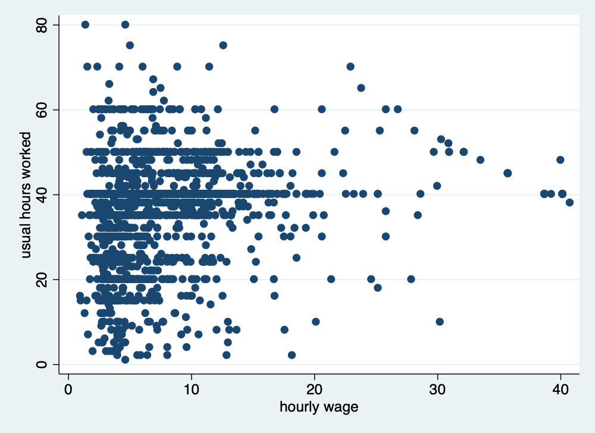

Hours and Wages

```stata
twoway scatter hours wage if hours > 0 & wage >0 & wage < 1000
graph export "hour_wage.png", width(500) replace
```

#### 4.7 Correcting errors in data

Let go ahead and fix some of these errors that we have found. A word of caution is that you may need to talk to the data stewards about the best ways to correct the data. You don’t want to attempt to fix the measurement error and introduce additional problems. Institutional knowledge of the data is very helpful before correcting errors.

Let’s fix when race was equal to 4 when there are only 3 categories.

```stata
list idcode race if race==4
replace race=1 if idcode == 543
tabulate race
```

```
      | idcode   race |
      |---------------|
2013. |    543      4 |
      +---------------+

(1 real change made)

       race |      Freq.     Percent        Cum.
------------+-----------------------------------
          1 |      1,637       72.89       72.89
          2 |        583       25.96       98.84
          3 |         26        1.16      100.00
------------+-----------------------------------
      Total |      2,246      100.00
```

Let’s add a note for future users, which is good practice for replication.

```stata
note race: race changed to 1 (from 4) for idcode 543
```

Let’s fix college gradudate when there were only 8 years of education.

```stata
list idcode collgrad if yrschool < 12 & collgrad == 1
replace collgrad = 0 if idcode == 107
tab yrschool collgrad
note collgrad: collgrad changed to 0 (from 1) for idcode 107
```

```
      | idcode   collgrad |
      |-------------------|
2198. |    107          1 |
      +-------------------+

(1 real change made)


  Years of |
    school |   college graduate
 completed |         0          1 |     Total
-----------+----------------------+----------
         8 |        70          0 |        70
         9 |        55          0 |        55
        10 |        84          0 |        84
        11 |       123          0 |       123
        12 |       943          0 |       943
        13 |       174          2 |       176
        14 |       180          7 |       187
        15 |        81         11 |        92
        16 |         0        252 |       252
        17 |         0        106 |       106
        18 |         0        154 |       154
-----------+----------------------+----------
     Total |     1,710        532 |     2,242
```

Let’s fix age which where the digits were switched.

```stata
list idcode age if age > 50
replace age = 38 if idcode == 51
replace age = 45 if idcode == 80
tab age
note age: the value of 83 was corrected to 38 for idcode 51
note age: the value of 54 was corrected to 45 for idcode 80
```

```
      | idcode   age |
      |--------------|
2205. |     80    54 |
2219. |     51    83 |
      +--------------+

(1 real change made)

(1 real change made)

     age in |
    current |
       year |      Freq.     Percent        Cum.
------------+-----------------------------------
         21 |          2        0.09        0.09
         22 |          8        0.36        0.45
         23 |         16        0.71        1.16
         24 |         35        1.56        2.72
         25 |         44        1.96        4.67
         26 |         50        2.23        6.90
         27 |         50        2.23        9.13
         28 |         63        2.80       11.93
         29 |         49        2.18       14.11
         30 |         55        2.45       16.56
         31 |         57        2.54       19.10
         32 |         60        2.67       21.77
         33 |         56        2.49       24.27
         34 |         95        4.23       28.50
         35 |        213        9.48       37.98
         36 |        224        9.97       47.95
         37 |        171        7.61       55.57
         38 |        176        7.84       63.40
         39 |        167        7.44       70.84
         40 |        139        6.19       77.03
         41 |        148        6.59       83.62
         42 |        111        4.94       88.56
         43 |        110        4.90       93.46
         44 |         98        4.36       97.82
         45 |         46        2.05       99.87
         46 |          1        0.04       99.91
         47 |          1        0.04       99.96
         48 |          1        0.04      100.00
------------+-----------------------------------
      Total |      2,246      100.00
```

Let’s look at our notes.

```stata
note
```

```
_dta:
  1.  This is a hypothetical dataset and should not be used for analysis purposes

age:
  1.  the value of 83 was corrected to 38 for idcode 51
  2.  the value of 54 was corrected to 45 for idcode 80

race:
  1.  race changed to 1 (from 4) for idcode 543

collgrad:
  1.  collgrad changed to 0 (from 1) for idcode 107
```

#### 4.8 Identifying duplicates

We need to be careful with duplicate observations. When working with panel data we will want multiple observations of the same cross-sectional unit, but there should be multiple observations for different time units and not the same time unit.

```stata
use "dentists_dups.dta", clear
```

We can start with our duplicates list command to find rows that are completely the same. This command will show all the duplicates. **Note:** for duplicate records to be found, all data needs to be the same.

```stata
duplicates list
```

```
Duplicates in terms of all variables

  +-----------------------------------------------------------+
  | group:   obs:             name   years   fulltime   recom |
  |-----------------------------------------------------------|
  |      1      4       Mike Avity     8.5          0       0 |
  |      1      6       Mike Avity     8.5          0       0 |
  |      1      8       Mike Avity     8.5          0       0 |
  |      2      1   Olive Tu'Drill   10.25          1       1 |
  |      2     11   Olive Tu'Drill   10.25          1       1 |
  |-----------------------------------------------------------|
  |      3      2     Ruth Canaale      22          1       1 |
  |      3      3     Ruth Canaale      22          1       1 |
  +-----------------------------------------------------------+
```

We’ll have a more condensed version with duplicates examples. It will give an example of the duplicate records for each group of duplicate records.

```stata
duplicates examples
```

```
Duplicates in terms of all variables

  +-------------------------------------------------------------------+
  | group:   #   e.g. obs             name   years   fulltime   recom |
  |-------------------------------------------------------------------|
  |      1   3          4       Mike Avity     8.5          0       0 |
  |      2   2          1   Olive Tu'Drill   10.25          1       1 |
  |      3   2          2     Ruth Canaale      22          1       1 |
  +-------------------------------------------------------------------+
```

We can find the a consice list of duplicate records with duplicates report.

```stata
duplicates report
```

```
Duplicates in terms of all variables

--------------------------------------
   copies | observations       surplus
----------+---------------------------
        1 |            4             0
        2 |            4             2
        3 |            3             2
--------------------------------------
```

The duplicates tag command can return the number of duplicates for each group of duplicates (note the separator option puts a line in the table after # rows.

```stata
duplicates tag, generate(dup)
list, separator(2)
```

```
Duplicates in terms of all variables

     +----------------------------------------------------+
     |              name   years   fulltime   recom   dup |
     |----------------------------------------------------|
  1. |    Olive Tu'Drill   10.25          1       1     1 |
  2. |      Ruth Canaale      22          1       1     1 |
     |----------------------------------------------------|
  3. |      Ruth Canaale      22          1       1     1 |
  4. |        Mike Avity     8.5          0       0     2 |
     |----------------------------------------------------|
  5. |        Mary Smith       3          1       1     0 |
  6. |        Mike Avity     8.5          0       0     2 |
     |----------------------------------------------------|
  7. | Y. Don Uflossmore    7.25          0       1     0 |
  8. |        Mike Avity     8.5          0       0     2 |
     |----------------------------------------------------|
  9. |        Mary Smith      27          0       0     0 |
 10. | Isaac O'Yerbreath   32.75          1       1     0 |
     |----------------------------------------------------|
 11. |    Olive Tu'Drill   10.25          1       1     1 |
     +----------------------------------------------------+
```

Let’s sort our data for better legibility, and then we will add lines in our output table whenever there is a new group.

```stata
    sort name years
    list, sepby(name years)
```

```
     |              name   years   fulltime   recom   dup |
     |----------------------------------------------------|
  1. | Isaac O'Yerbreath   32.75          1       1     0 |
     |----------------------------------------------------|
  2. |        Mary Smith       3          1       1     0 |
     |----------------------------------------------------|
  3. |        Mary Smith      27          0       0     0 |
     |----------------------------------------------------|
  4. |        Mike Avity     8.5          0       0     2 |
  5. |        Mike Avity     8.5          0       0     2 |
  6. |        Mike Avity     8.5          0       0     2 |
     |----------------------------------------------------|
  7. |    Olive Tu'Drill   10.25          1       1     1 |
  8. |    Olive Tu'Drill   10.25          1       1     1 |
     |----------------------------------------------------|
  9. |      Ruth Canaale      22          1       1     1 |
 10. |      Ruth Canaale      22          1       1     1 |
     |----------------------------------------------------|
 11. | Y. Don Uflossmore    7.25          0       1     0 |
     +----------------------------------------------------+
```

**Notice:** There are two observations for Mary Smith, but one has 3 years of experience and the other one has 27 years, so it does not appear as a duplicate.

If there were too many variables, which could use our data browser.

```stata
browse if dup > 0
```

```
request ignored because of batch mode
```

We will want to drop our duplicates, but not the first observation. The duplicates drop command will drop the duplicate records but still keep one observation of the duplicate group.

```
duplicates drop
```

Let’s use a new dataset that is a bit more practical.

```stata
use "wws.dta", replace
```

Use *duplicates list* for the variable of interest

```stata
duplicates list idcode
```

```
Duplicates in terms of idcode

(0 observations are duplicates)
```

There are no duplicate idcodes, so we should expect that duplicates list will not return any duplicates, since every single values needs to be the same for there to be a dupicate record.

```stata
duplicates list
```

```
Duplicates in terms of all variables

(0 observations are duplicates)
```

Let’s use a dataset that does have duplicates.

```stata
use "wws_dups.dta", clear
```

Let’s check for duplicate idcodes.

```stata
duplicates list idcode, sepby(idcode)
```

```
Duplicates in terms of idcode

  +------------------------+
  | group:   obs:   idcode |
  |------------------------|
  |      1   1088     2831 |
  |      1   2248     2831 |
  |------------------------|
  |      2   1244     3905 |
  |      2   1245     3905 |
  |------------------------|
  |      3    277     4214 |
  |      3   2247     4214 |
  +------------------------+
```

I prefer duplicates list var1 instead of isid, since an error will break the do file using isid.

Let’s generate our dup variable for identifying the number of duplicates per group of duplicates.

```stata
duplicates tag idcode, generate(iddup)
```

```
Duplicates in terms of idcode
```

Let’s generate a different duplicate variable to find complete duplicate records. Notice that we do not specify a variable after tag.

```stata
duplicates tag, generate(alldup)
```

```
Duplicates in terms of all variables
```

Let’s list the data.

```stata
list idcode age race yrschool occupation wage if iddup==1 & alldup==0
```

```
      | idcode   age   race   yrschool   occupa~n       wage |
      |------------------------------------------------------|
1244. |   3905    36      1         14         11   4.339774 |
1245. |   3905    41      1         10          5   7.004828 |
      +------------------------------------------------------+
```

It seems that idcode 3905 is a different person with a possible incorrect idcode. Let’s fix that.

```stata
replace idcode=5160 if idcode==3905 & age==41
```

Let’s see if it is resolved, and it is.

```stata
list idcode age race yrschool occupation wage if iddup==1 & alldup==0
```

```
      | idcode   age   race   yrschool   occupa~n       wage |
      |------------------------------------------------------|
1244. |   3905    36      1         14         11   4.339774 |
1245. |   5160    41      1         10          5   7.004828 |
      +------------------------------------------------------+
```

Let’s look observation that are complete duplicates.

```stata
duplicates report
list idcode age race yrschool occupation wage if iddup==1 & alldup==1
```

```
Duplicates in terms of all variables

--------------------------------------
   copies | observations       surplus
----------+---------------------------
        1 |         2244             0
        2 |            4             2
--------------------------------------

      +------------------------------------------------------+
      | idcode   age   race   yrschool   occupa~n       wage |
      |------------------------------------------------------|
 277. |   4214    35      1         17         13   11.27214 |
1088. |   2831    37      2          8          8   2.697261 |
2247. |   4214    35      1         17         13   11.27214 |
2248. |   2831    37      2          8          8   2.697261 |
      +------------------------------------------------------+
```

We need to keep 1 observation of the duplicates

```stata
duplicates drop
duplicates report
```

```
Duplicates in terms of all variables

(2 observations deleted)


Duplicates in terms of all variables

--------------------------------------
   copies | observations       surplus
----------+---------------------------
        1 |         2246             0
--------------------------------------
```

### Practice

Let’s work the Census CPS. Pull the Census CPS. 1. You can download the file and import it, or 2. You can use Stata to pull the file.

```stata
import delimited using "https://www2.census.gov/programs-surveys/cps/datasets/2023/basic/jun23pub.csv", clear
```

Let’s save a copy of the csv file in Stata.

Let’s grab the data dictionary. Hint search: “Census CPS 2023 data dictionary”

Let’s check our data.

1. What variable contains our laborforce status?
2. What variable contains our weekly earnings?
3. Does everyone employed have weekly earnings? Hint: Try summarize
4. What flag with our weekly earning that provides information about available data?
5. Try tabstat with the flag and weekly earnings. What do you find?
6. Try tabstat with statistics(n mean sd p25 p50 p75)
7. What are our identifier variable(s)? How many did you find?
8. Are there any duplicate records?